# KNN para el análisis de variables cuantitativas con R

# 1 Introducción

Se quiere predecir el peso de dos pingüinos con las siguientes características:

```
##   especie   isla long_pico prof_pico long_aleta genero
## 1  Adelie  Dream      39.8      18.4        192 hembra
## 2  Gentoo Biscoe      46.1      15.5        202  macho
```

utilizando los datos del archivo pinguinos.csv y el algoritmo KNN.

# 2 Lectura y preparación de los datos

En primer lugar se leen los datos y se crean los factores correspondientes

```r
## se leen los datos
d = read.csv("datos/pinguinos.csv", sep = ";")
```

```r
# es conveniente convertir a factores las variables cualitativas
d$especie = factor(d$especie)
d$isla = factor(d$isla)
d$genero = factor(d$genero)
```

- Se normalizan los regresores numéricos (descargar knn_funciones.R):

```r
# se lee la funcion que normaliza
source("funciones/knn_funciones.R")
```

```r
# se normalizan y se guardan en un data.frame
d1 = data.frame(
  long_pico = knn_normaliza(d$long_pico),
  prof_pico = knn_normaliza(d$prof_pico),
  long_aleta = knn_normaliza(d$long_aleta)
)
```

- Se definen las variables auxiliares. En este caso se decide utilizar tantas variables auxiliares como niveles del factor:

```r
d1$especie_Ade = ifelse(d$especie == "Adelie", 1, 0)
d1$especie_Chi = ifelse(d$especie == "Chinstrap", 1, 0)
d1$especie_Gen = ifelse(d$especie == "Gentoo", 1, 0)
#
d1$isla_Bis = ifelse(d$isla == "Biscoe", 1, 0)
d1$isla_Dre = ifelse(d$isla == "Dream", 1, 0)
d1$isla_Tor = ifelse(d$isla == "Torgersen", 1, 0)
#
d1$genero_H = ifelse(d$genero == "hembra", 1, 0)
d1$genero_M = ifelse(d$genero == "macho", 1, 0)
```

- Se preparan los valores que se quieren predecir:

```r
# variables cuantitativas normalizadas
xp1 = data.frame(
  long_pico = knn_normaliza(c(39.8,46.1), min(d$long_pico), max(d$long_pico)),
  prof_pico = knn_normaliza(c(18.4,15.5), min(d$prof_pico), max(d$prof_pico)),
  long_aleta = knn_normaliza(c(192,202), min(d$long_aleta), max(d$long_aleta))
)
# variables auxiliares
xp1$especie_Ade = c(1,0)
xp1$especie_Chi = c(0,0)
xp1$especie_Gen = c(0,1)
#
xp1$isla_Bis = c(0,1)
xp1$isla_Dre = c(1,0)
xp1$isla_Tor = c(0,0)
#
xp1$genero_H = c(1,0)
xp1$genero_M = c(0,1)
```

# 3 Algoritmo KNN con R

Para aplicar el algoritmo se va a utilizar el paquete FNN de R. Este paquete no viene instalado por defecto, por lo que hay que instalarlo y activarlo para poder usar las funciones incluidas en dicho paquete:

```r
# se instala el paquete
# install.packages("FNN")
# se activa el paquete
# library(FNN)
```

Otra alternativa es utilizar las funciones mediante la forma **paquete::funcion**. En este caso, para k = 1 la predicción es:

```r
# se utiliza la funcion knn.reg del paquete FNN
yp = FNN::knn.reg(d1, test = xp1, y = d$peso, k = 1)
yp$pred
```

```
## [1] 3600 5350
```

# 4 Calcular el mejor valor de K

## 4.1 Método del subconjunto de entrenamiento y el subconjunto de validación (train set - test set)

- Se dividen los datos en dos partes: datos de entrenamiento y datos de validación. Esta división suele ser aleatoria. El tamaño de los datos de entrenamiento tiene que ser mayor (80%-20%, 70%-30%,…).
- Para varios valores de k:
  - En el **training set** se estima el modelo.
  - En el **test set** se predice la respuesta y se calcula el error entre la variable respuesta observada $y_i$ y la predicha $\hat y_i$. Para calcular el error se puede utilizar, por ejemplo, el Error Cuadrático Medio (ECM)

$$ECM = \frac{1}{n}\sum _{i=1}^{n}{(y_i - \hat y_i)^2}$$

o la raíz del error cuadrático medio (es preferible porque tiene las mismas unidades que la variable respuesta):

$$RECM = \sqrt{\frac{1}{n}\sum _{i=1}^{n}{(y_i - \hat y_i)^2}}$$

- Se elige el valor de k con el menor error de predicción en el test set.

```r
# se crean los datos de entrenamiento y los datos test (80%-20%)
set.seed(123)
n = nrow(d)
pos_train = sample(1:n,round(0.8*n), replace = F)
train_x = d1[pos_train,]
test_x = d1[-pos_train,]
train_y = d$peso[pos_train]
test_y = d$peso[-pos_train]
```

```r
# se utiliza la funcion knn.reg del paquete FNN
yp = FNN::knn.reg(train_x, test = test_x, y = train_y, k = 1)
# se calcula el error con RECM
error = test_y - yp$pred
sqrt(mean(error^2))
```

```
## [1] 399.9767
```

```r
# se calcula el error para distintos valores de k y se elige el que tenga menor error
recm = rep(0,20)
for (ii in 1:20){
  yp = FNN::knn.reg(train_x, test = test_x, y = train_y, k = ii)
  error = test_y - yp$pred
  recm[ii] = sqrt(mean(error^2))
}
```

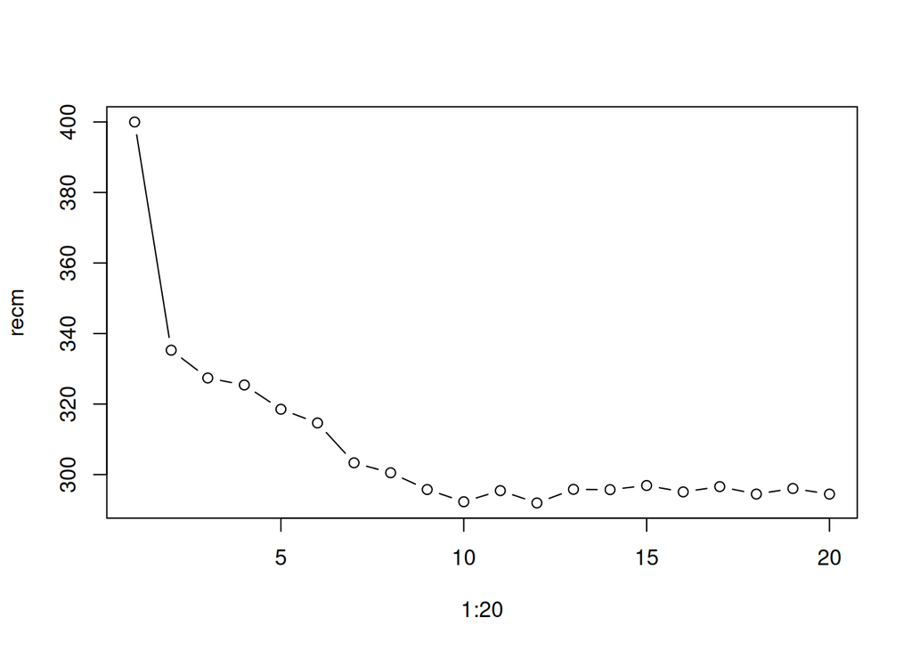

```r
plot(1:20,recm, type = "b")
```

A partir de k = 10 el error se estabiliza, luego elegimos este valor para calcular la predicción final:

```r
# se utilizan todos los datos
yp = FNN::knn.reg(d1, test = xp1, y = d$peso, k = 10)
yp$pred
```

```
## [1] 3467.5 5385.0
```

## 4.2 Método de validacion cruzada

### 4.2.1 Definición

Se dividen aleatoriamente los datos en **S** subconjuntos de datos. Cada subconjunto tendrá, por tanto, n1 = n/S datos.

- Para i = 1:S
  - el subconjunto i constituye el test set.
  - los otros subconjuntos constituyen el train set.
  - se estima el modelo en el train set y se predice la variable respuesta en el test set.
  - se calcula el error de predicción en el test set: $ECM_i$ (en caso de utilizar el error cuadrático medio).
- El error total calculado con validación cruzada es la media de todos los subconjuntos:

$$ECM_{TOTAL} = \frac{1}{S} \sum _{i=1}^S ECM_i$$

### 4.2.2 Leave-one-out cross validation

La opción más sencilla de aplicar validación cruzada es cuando *S = n* lo que va a generar *n* subconjuntos train de tamaño *n-1* y *n* subconjuntos test de tamaño 1. Por ejemplo, se tenemos tres datos (1,2,3), los subconjutos train-test serían: (1,2)-(3), (1,3)-(2), (2,3)-(1). A esta forma de organizar la validación cruzada se le conoce como **Leave one out cross-validation**.

```r
# segun la ayuda, si no se proporciona el test set entonces knn.reg aplica Leave one out cross-validation
yp = FNN::knn.reg(d1, y = d$peso, k = 1)
str(yp)
```

```
## List of 7
##  $ call     : language FNN::knn.reg(train = d1, y = d$peso, k = 1)
##  $ k        : num 1
##  $ n        : int 333
##  $ pred     : num [1:333] 3900 2900 3275 3450 3800 ...
##  $ residuals: num [1:333] -150 900 -25 0 -150 ...
##  $ PRESS    : num 52765000
##  $ R2Pred   : num 0.755
##  - attr(*, "class")= chr "knnRegCV"
```

- Se generan 333 predicciones ya que S = 333.
- Y por tanto 333 errores de predicción (residuos).
- El error se mide con la suma de los residuos al cuadrado (PRESS):

$$Residuos: \ e_i = y_i - \hat{y}_i$$

$$PRESS = \sum e_i^2$$

```r
sum(yp$residuals^2)
```

```
## [1] 52765000
```

- Y también se mide con el R-cuadrado:

$$R^2 = 1 - \frac{\sum e_i^2}{\sum (y_i-\bar y)^2}$$

- Cuando $R^2 \approx 1 \Rightarrow$, los residuos son muy pequeños, la predicción es buena.
- Cuando $R^2 \approx 0 \Rightarrow$ los errores son tan grandes como los datos predichos, la predicción es mala.

```r
1 - sum(yp$residuals^2)/((n-1)*var(d$peso))
```

```
## [1] 0.7548774
```

- Por ejemplo, utilizando la suma de residuos al cuadrado como medida del error se puede calcular el mejor valor de k:

```r
error = rep(0,20)
for (ii in 1:20){
  yp = FNN::knn.reg(d1, y = d$peso, k = ii)
  error[ii] = yp$PRESS
}
```

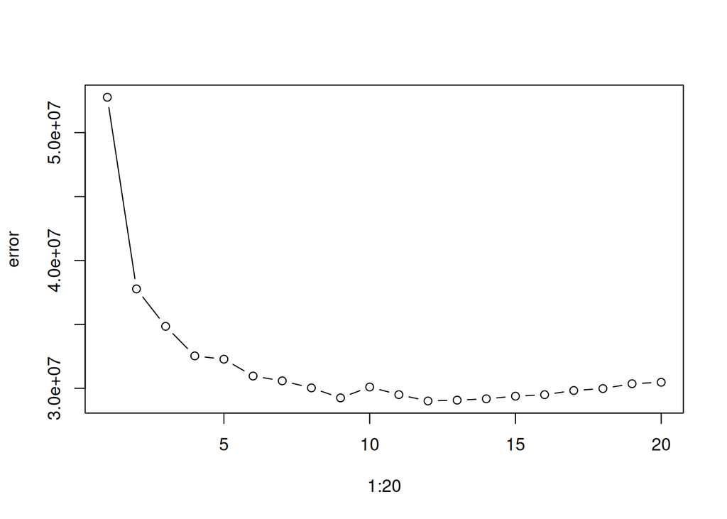

```r
plot(1:20,error, type = "b")
```

A partir de k= 9 el error se estabiliza, luego elegimos este valor. Ahora se puede calcular la predicción final:

```r
# se utilizan todos los datos
yp = FNN::knn.reg(d1, test = xp1, y = d$peso, k = 9)
yp$pred
```

```
## [1] 3469.444 5383.333
```

## 4.3 Validación cruzada con m subconjuntos de datos

Otra opción es utilizar validación cruzada con un número menor de subconjuntos, por ejemplo, 5 subconjuntos. Se ha programado una funcion que calcula las posiciones de train y test dado el número de subconjuntos (descargar):

```r
source("funciones/validacion_cruzada.R")
validacion_cruz_pos # se muestra el contenido de la función
```

```
## function(num_datos,num_sub){
##   # -------------------------------------------------------------------
##   # esta funcion calcula las posiciones que corresponden al train
##   # y las posiciones que corresponden al test en validacion cruzada
##   #
##   # num_datos: numero de datos
##   # num_sub: numero de subconjuntos
##   #
##   # javier.cara@upm.es, version 2025.09
##   # ------------------------------------------------------------------
##
##   # numero de datos de cada subconjuntos
##   n1 = trunc(num_datos/num_sub)
##
##   v = sample(1:num_datos,num_datos,replace = F)
##   train = list()
##   test = list()
##   for (k in 1:(num_sub-1)){
##     pos_test = ((k-1)*n1+1):(k*n1)
##     test[[k]] = v[pos_test]
##     train[[k]] = v[-pos_test]
##   }
##   # el ultimo puede tener un numero diferente de datos (por trunc)
##   pos_test = ((num_sub-1)*n1+1):num_datos
##   test[[num_sub]] = v[pos_test]
##   train[[num_sub]] = v[-pos_test]
##
##   return(list(num_sub = num_sub, train = train, test = test))
## }
```

Por ejemplo, supongamos que tenemos 10 datos y definimos 3 folds:

```r
set.seed(342)
num_datos = 10
num_sub = 3
validacion_cruz_pos(num_datos,num_sub)
```

```
## $num_sub
## [1] 3
##
## $train
## $train[[1]]
## [1] 7 4 1 9 8 6 3
##
## $train[[2]]
## [1] 10  5  2  9  8  6  3
##
## $train[[3]]
## [1] 10  5  2  7  4  1
##
##
## $test
## $test[[1]]
## [1] 10  5  2
##
## $test[[2]]
## [1] 7 4 1
##
## $test[[3]]
## [1] 9 8 6 3
```

Con dicha función se puede utilizar validación cruzada con 5 subconjuntos para calcular el k óptimo:

```r
set.seed(111)

# numero de sub
num_sub = 5
n = nrow(d)

# se definen las posiciones de test de cada subconj
pos = validacion_cruz_pos(n,num_sub)

error_i = rep(0,20)
for (i in 1:20){
  error_j = rep(0,num_sub)
  for (j in 1:num_sub){
    # datos de training y de test de cada fold
    pos_test = pos$test[[j]]
    pos_train = pos$train[[j]]
    train = d1[pos_train,]
    test = d1[pos_test,]

    # knn
    yp = FNN::knn.reg(train, test, y = d$peso[pos_train], k = i)

    # error de prediccion
    yi = d$peso[pos_test]
    yi_p = yp$pred
    error_j[j] = sqrt(mean((yi-yi_p)^2)) # RECM
  }
  error_i[i] = mean(error_j)
}
```

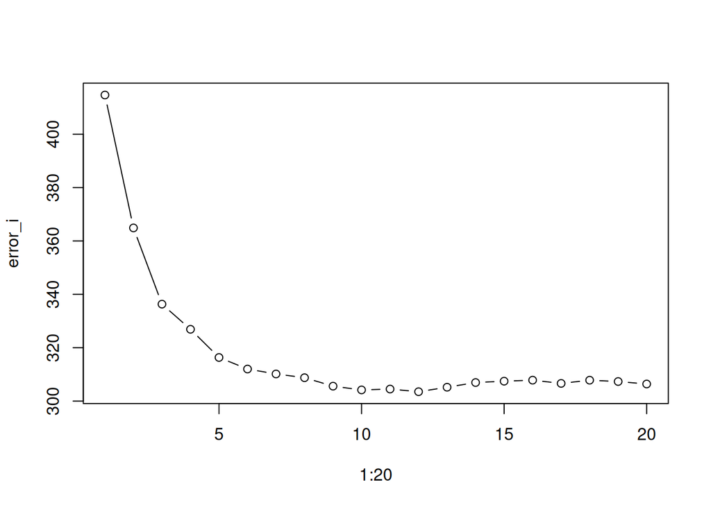

```r
plot(1:20,error_i, type = "b")
```

Como se observa, también se puede elegir k = 9, k = 10.